# Verzani Problem Set

Next are considered the problems from Verzani’s book on page $83$.

## Problem 13.1

The cost of a home depends on the number of bedrooms in the house. Suppose the following data is recorded for homes in a given town

| price (in thousands) | 300 | 250 | 400 | 550 | 317 | 389 | 425 | 289 | 389 | 559 |
| --- | --- | --- | --- | --- | --- | --- | --- | --- | --- | --- |
| Number of bedrooms | 3 | 3 | 4 | 5 | 4 | 3 | 6 | 3 | 4 | 5 |

Make a scatterplot, and fit the data with a regression line. On the same graph, test the hypothesis that an extra bedroom costs $\$60,000$ against the alternative that it costs more.

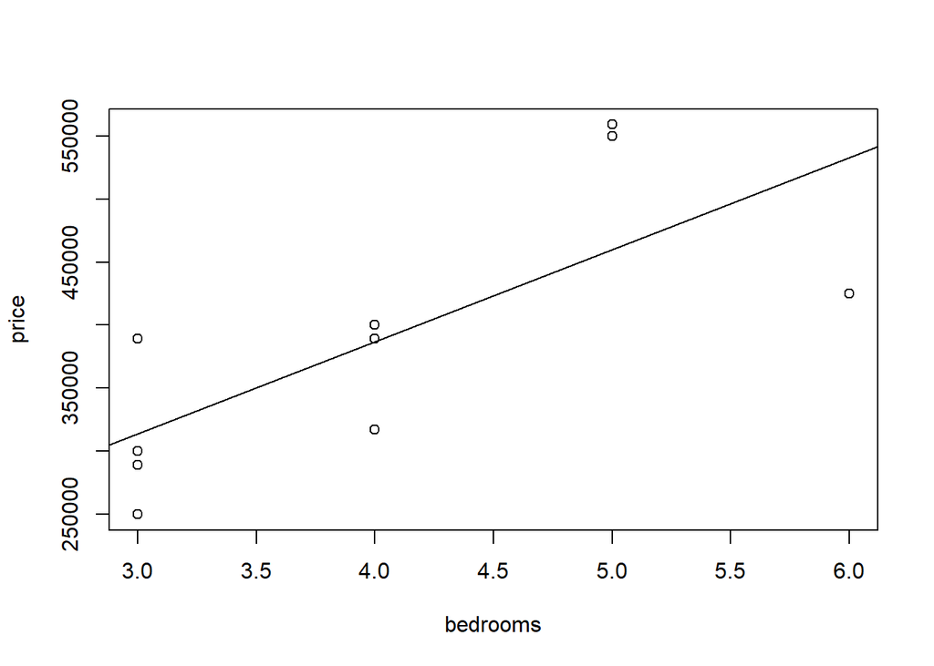

```r
> price <- c(300000, 250000, 400000, 550000, 317000, 389000, 425000, 289000, 389000, 559000)
> bedrooms <- c(3, 3, 4, 5, 4, 3, 6, 3, 4, 5)
> lmResult <- lm(price ~ bedrooms)
> summary(lmResult)

Call:
lm(formula = price ~ bedrooms)

Residuals:
    Min      1Q  Median      3Q     Max
-108000  -53950   -5750   59775   99100

Coefficients:
            Estimate Std. Error t value Pr(>|t|)
(Intercept)    94400      97983   0.963   0.3635
bedrooms       73100      23764   3.076   0.0152 *
---
Signif. codes:  0 '***' 0.001 '**' 0.01 '*' 0.05 '.' 0.1 ' ' 1

Residual standard error: 75150 on 8 degrees of freedom
Multiple R-squared:  0.5419,    Adjusted R-squared:  0.4846
F-statistic: 9.462 on 1 and 8 DF,  p-value: 0.01521
> plot(bedrooms, price)
> abline(lmResult)
```

$H_0 : \beta_1 = 60000$

$H_1 : \beta_1 > 60000$

$$S_\varepsilon^2 = \frac{\sum{\varepsilon_i^2}}{n - 2}$$
$$SE(\beta_1) = \frac{S_\varepsilon}{\sqrt{\sum{(X_i - \bar{X}_n)^2}}}$$
$$\left(\left.\frac{\hat{\beta_1} - b_1}{SE(\beta_1)}\right|H_0\right) \in t(n-2)$$

Given $\alpha$ the critical area is

$$W_\alpha =\left\{\frac{\hat{\beta}_1 - b_1}{SE(\beta_1)} \geq t_{1-\alpha; n-2}\right\}$$

```r
> e <- resid(lmResult); e
      1       2       3       4       5       6       7       8       9      10
 -13700  -63700   13200   90100  -69800   75300 -108000  -24700    2200   99100
> n <- length(e)
> Seps <- sqrt(sum(e^2) / (n - 2)); Seps
[1] 75149.43
> beta1hat <- coef(lmResult)[['bedrooms']]; beta1hat
[1] 73100
> SEbeta1 <- Seps / sqrt(sum((bedrooms - mean(bedrooms))^2)); SEbeta1
[1] 23764.34
> b1 <- 60000
> t <- (beta1hat - b1) / SEbeta1; t
[1] 0.5512462
> pvalue <- pt(t, n - 2, lower.tail = FALSE);pvalue
[1] 0.2982602
```

The $p-value = 0.2982602 > 0.05 = \alpha$, so we have no evidence to reject $H_0$. An extra bedroom costs $\$60,000$.

Some of the values, for example $S_\varepsilon$, $\hat{\beta}_1$, $SS(\beta_1)$ could be taken from the output of `summary(lmResult)`.

## Problem 13.2

It is well known that the more beer you drink, the more your blood alcohol level rises. Suppose we have the following data on student beer consumption

| Student | 1 | 2 | 3 | 4 | 5 | 6 | 7 | 8 | 9 | 10 |
| --- | --- | --- | --- | --- | --- | --- | --- | --- | --- | --- |
| Beers | 5 | 2 | 9 | 8 | 3 | 7 | 3 | 5 | 3 | 5 |
| BAL | 0.10 | 0.03 | 0.19 | 0.12 | 0.04 | 0.095 | 0.07 | 0.06 | 0.02 | 0.05 |

Make a scatterplot and fit the data with a regression line. Test the hypothesis that another beer raises your BAL by $0.02$ percent against the alternative that it is less.

```r
> Beers <- c(5, 2, 9, 8, 3, 7, 3, 5, 3, 5)
> BAL <- c(0.10, 0.03, 0.19, 0.12, 0.04, 0.095, 0.07, 0.06, 0.02, 0.05)
```

$H_0 : \beta_1 = 0.02$

$H_A : \beta_1 < 0.02$

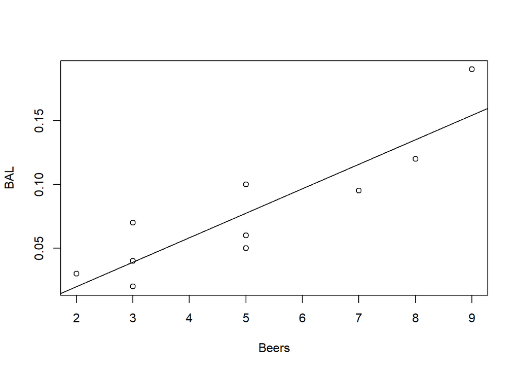

```r
> lmResult <- lm(BAL ~ Beers)
> summary(lmResult)

Call:
lm(formula = BAL ~ Beers)

Residuals:
    Min      1Q  Median      3Q     Max
-0.0275 -0.0187 -0.0071  0.0194  0.0357

Coefficients:
             Estimate Std. Error t value Pr(>|t|)
(Intercept) -0.018500   0.019230  -0.962 0.364200
Beers        0.019200   0.003511   5.469 0.000595 ***
---
Signif. codes:  0 '***' 0.001 '**' 0.01 '*' 0.05 '.' 0.1 ' ' 1

Residual standard error: 0.02483 on 8 degrees of freedom
Multiple R-squared:  0.789, Adjusted R-squared:  0.7626
F-statistic: 29.91 on 1 and 8 DF,  p-value: 0.0005953
> plot(Beers, BAL)
> abline(lmResult)
```

```r
> e <- resid(lmResult); e
      1       2       3       4       5       6       7       8       9      10
 0.0225  0.0101  0.0357 -0.0151  0.0009 -0.0209  0.0309 -0.0175 -0.0191 -0.0275
> n <- length(e)
> Seps <- sqrt(sum(e^2) / (n - 2)); Seps
[1] 0.02482564
> beta1hat <- coef(lmResult)[['Beers']]; beta1hat
[1] 0.0192
> SEbeta1 <- Seps / sqrt(sum((Beers - mean(Beers))^2)); SEbeta1
[1] 0.003510876
> b1 <- 0.02
> t <- (b1 - beta1hat) / SEbeta1; t
[1] 0.2278634
> pvalue <- pt(t, n - 2, lower.tail = TRUE);pvalue
[1] 0.5872658
```

The $p-value = 0.5872658 > 0.05 = \alpha$, so we have no evidence to reject $H_0$. Another beer raises your BAL by $0.02$ percent or more.

## Problem 13.3

For the same Blood alcohol data, do a hypothesis test that the intercept is $0$ with a two-sided alternative.

```r
> Beers <- c(5, 2, 9, 8, 3, 7, 3, 5, 3, 5)
> BAL <- c(0.10, 0.03, 0.19, 0.12, 0.04, 0.095, 0.07, 0.06, 0.02, 0.05)
```

$H_0 : \beta_0 = 0$

$H_1 : \beta_0 \neq 0$

```r
> lmResult <- lm(BAL ~ Beers)
> summary(lmResult)

Call:
lm(formula = BAL ~ Beers)

Residuals:
    Min      1Q  Median      3Q     Max
-0.0275 -0.0187 -0.0071  0.0194  0.0357

Coefficients:
             Estimate Std. Error t value Pr(>|t|)
(Intercept) -0.018500   0.019230  -0.962 0.364200
Beers        0.019200   0.003511   5.469 0.000595 ***
---
Signif. codes:  0 '***' 0.001 '**' 0.01 '*' 0.05 '.' 0.1 ' ' 1

Residual standard error: 0.02483 on 8 degrees of freedom
Multiple R-squared:  0.789, Adjusted R-squared:  0.7626
F-statistic: 29.91 on 1 and 8 DF,  p-value: 0.0005953
```

The $p-value = 0.3642 > 0.05 = \alpha$, so we have no evidence to reject $H_0$.

## Problem 13.4

The lapse rate is the rate at which temperature drops as you increase elevation. Some hardy students were interested in checking empirically if the lapse rate of $9.8$ degrees C/km was accurate for their hiking. To investigate, they grabbed their thermometers and their Suunto wrist altimeters and found the following data on their hike

| elevation (ft) | 600 | 1000 | 1250 | 1600 | 1800 | 2100 | 2500 | 2900 |
| --- | --- | --- | --- | --- | --- | --- | --- | --- |
| temperature (F) | 56 | 54 | 56 | 50 | 47 | 49 | 47 | 45 |

Draw a scatter plot with regression line, and investigate if the lapse rate is $9.8C/km$. (First, it helps to convert to the rate of change in Fahrenheit per feet with is $5.34$ degrees per $1000$ feet.) Test the hypothesis that the lapse rate is $5.34$ degrees per $1000$ feet against the alternative that it is less than this.

According to the conditions we have to check if the regression equation is
$$y = \beta_0-5,34x$$

Let us first build up our simple linear regression model and then to test the hypothesis if the slope is $\beta_1 = -5,34$.

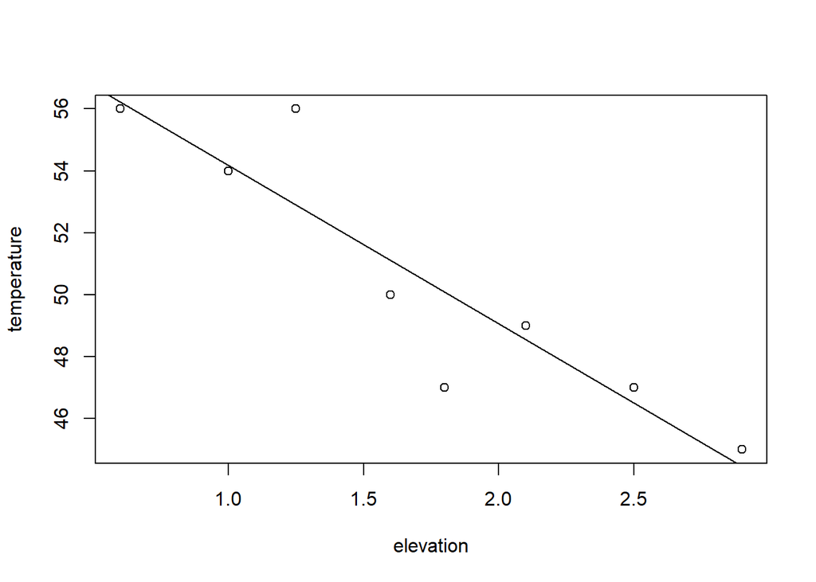

```r
> elevation <- c(600, 1000, 1250, 1600, 1800, 2100, 2500, 2900) / 1000
> temperature <- c(56, 54, 56, 50, 47, 49, 47, 45)
> lmResult <- lm(temperature ~ elevation)
> plot(elevation, temperature)
> abline(lmResult)
```

We test

$H_0 : \beta_1 = -5,34$

$H_A : \beta_1 < -5,34$

```r
> summary(lmResult)

Call:
lm(formula = temperature ~ elevation)

Residuals:
    Min      1Q  Median      3Q     Max
-3.0844 -0.4433  0.1369  0.5072  3.1025

Coefficients:
            Estimate Std. Error t value Pr(>|t|)
(Intercept)  59.2907     1.7173  34.525 3.93e-08 ***
elevation    -5.1146     0.9214  -5.551  0.00144 **
---
Signif. codes:  0 '***' 0.001 '**' 0.01 '*' 0.05 '.' 0.1 ' ' 1

Residual standard error: 1.879 on 6 degrees of freedom
Multiple R-squared:  0.837, Adjusted R-squared:  0.8099
F-statistic: 30.81 on 1 and 6 DF,  p-value: 0.001445
```

We can take $\beta_1$ and $SE(\beta_1)$ values from the output of the function `summary` however the rest of those in
$$W_\alpha =\left\{\frac{\hat{\beta}_1 - b_1}{SE(\beta_1)} < t_{\alpha; n-2}\right\}, \quad SE(\beta_1) := \frac{S_\varepsilon}{\sqrt{\sum{(X_i - \bar{X_n})^2}}}$$
we have to compute them step by step

```r
> e <- resid(lmResult)
> n <- length(e)
> beta1hat <- (coef(lmResult))[['elevation']]; beta1hat
[1] -5.114567
> Seps <- sqrt(sum(e^2) / (n-2))
> SEbeta1 <- Seps / sqrt(sum((elevation - mean(elevation))^2)); SEbeta1
[1] 0.9213715
> alpha <- 0.05
> tquantile <- qt(alpha, n - 2, lower.tail = TRUE); tquantile
[1] -1.94318
> const <- -5.34
> temp <- (const - beta1hat) / SEbeta1; temp
[1] -0.2446712
> pvalue <- pt(temp, n - 2, lower.tail = TRUE); pvalue
[1] 0.4074318
```

See also the outputs of `summary(lmResult)`.

The $p-value = 0.4074318 > 0.05 = \alpha$, so we have no evidence to reject $H_0$ and according to the sample the difference between $\hat{\beta}_1 = -5.114567$ and the tested value $-5,34$ is not statistically significant.